# Wage Gap

Author: MFA - Stream A - Group 7

# 1 Omega Group plc- Pay Discrimination

At the last board meeting of Omega Group Plc., the headquarters of a large multinational company, the issue was raised that women were being discriminated in the company, in the sense that the salaries were not the same for male and female executives. A quick analysis of a sample of 50 employees (of which 24 men and 26 women) revealed that the average salary for men was about 8,700 higher than for women. This seemed like a considerable difference, so it was decided that a further analysis of the company salaries was warranted.

Our objective is to find out whether there is indeed a significant difference between the salaries of men and women, and whether the difference is due to discrimination or whether it is based on another, possibly valid, determining factor.

## 1.1 Loading the data

Lets first load the data and get a glimpse of it.

```r
omega <- read_csv(here::here("data", "omega.csv"))
glimpse(omega) # examine the data frame
```

```
## Rows: 50
## Columns: 3
## $ salary     <dbl> 81894, 69517, 68589, 74881, 65598, 76840, 78800, 70033, 63…
## $ gender     <chr> "male", "male", "male", "male", "male", "male", "male", "m…
## $ experience <dbl> 16, 25, 15, 33, 16, 19, 32, 34, 1, 44, 7, 14, 33, 19, 24, …
```

## 1.2 Relationship Salary - Gender ?

The data frame `omega` contains the salaries for the sample of 50 executives in the company. Can you conclude that there is a significant difference between the salaries of the male and female executives?

In the code below, we will create summary statistics on salary by gender. Also, we will create and print a dataframe where, for each gender, we show the mean, SD, sample size, the t-critical, the SE, the margin of error, and the low/high endpoints of a 95% condifence interval.

```r
# Summary Statistics of salary by gender
mosaic::favstats (salary ~ gender, data=omega)
```

```
##   gender   min    Q1 median    Q3   max  mean   sd  n missing
## 1 female 47033 60338  64618 70033 78800 64543 7567 26       0
## 2   male 54768 68331  74675 78568 84576 73239 7463 24       0
```

```r
# Dataframe with two rows (male-female) and having as columns gender, mean, SD, sample size,
  omega %>%
  group_by(gender) %>%
  summarise(mean_salary = mean(salary),
            sd_salary = sd(salary),
            sample_size=n(),
# the t-critical value, the standard error, the margin of error,
            t_critical=qt(0.975,sample_size-1),
            se_salary=(sd(salary)/sqrt(sample_size)),
            margin_se=t_critical*se_salary,
# and the low/high endpoints of a 95% confidence interval
            salary_low=mean_salary-margin_se,
            salary_high=mean_salary+margin_se)
```

```
## # A tibble: 2 x 9
##   gender mean_salary sd_salary sample_size t_critical se_salary margin_se
##   <chr>        <dbl>     <dbl>       <int>      <dbl>     <dbl>     <dbl>
## 1 female      64543.     7567.          26       2.06     1484.     3056.
## 2 male        73239.     7463.          24       2.07     1523.     3151.
## # … with 2 more variables: salary_low <dbl>, salary_high <dbl>
```

> From the summary table, we see that the average, median, min, max and quantile salary results all points to male executives having higher salaries than female ones. Therefore, according to the summary data, it is likely that male executives have significantly higher salary than females ones. From the second data frame, we can see that the 95% CI of male and female executive salaries do not overlap with each other. This indicates that male executives indeed have higher salaries.

We can also run a hypothesis testing, assuming as a null hypothesis that the mean difference in salaries is zero, or that, on average, men and women make the same amount of money.

```r
# hypothesis testing using t.test()
t.test(salary~gender,data=omega)
```

```
##
##  Welch Two Sample t-test
##
## data:  salary by gender
## t = -4, df = 48, p-value = 2e-04
## alternative hypothesis: true difference in means is not equal to 0
## 95 percent confidence interval:
##  -12973  -4420
## sample estimates:
## mean in group female   mean in group male
##                64543                73239
```

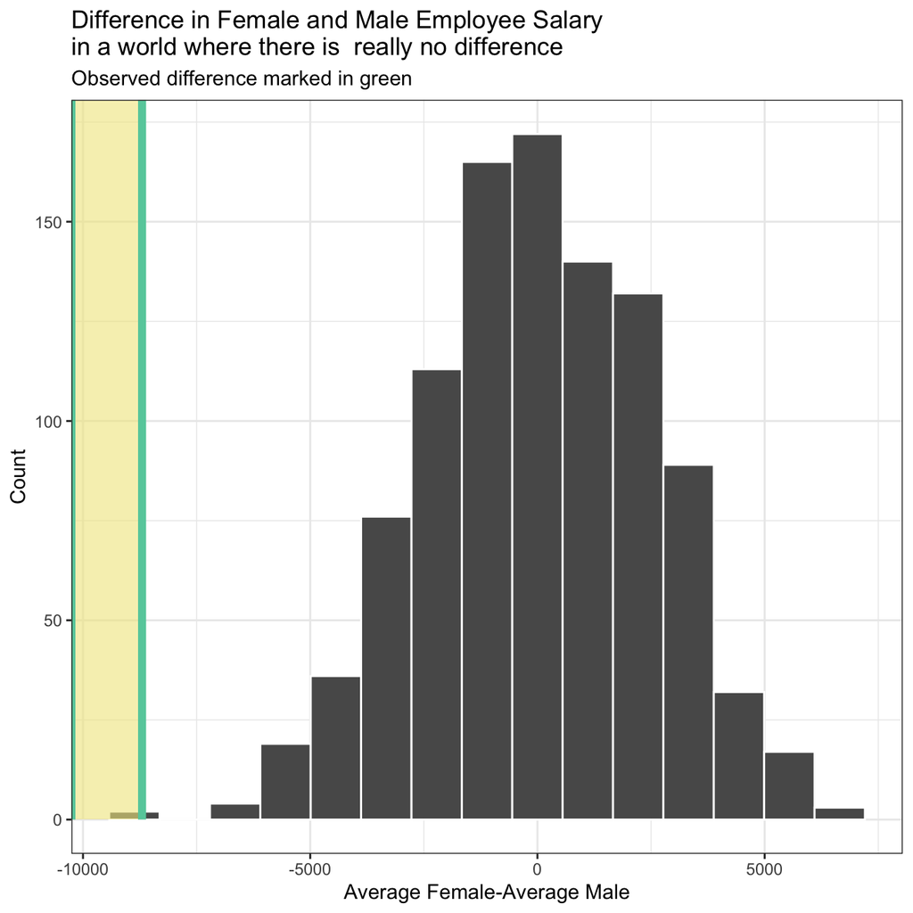

```r
# hypothesis testing using infer package
set.seed(1212)
salary_in_null_world <- omega %>%
  #specify the variable of interest
  specify(salary~gender) %>%
  #Hypothesize a null of no difference
  hypothesise(null="independence") %>%
  #Generate a bunch of simulated samples
  generate(reps = 1000, type="permute") %>%
  #Find the mean difference of each sample
  calculate(stat="diff in means",
            order = c("female","male"))

#Visualize data and check where the observed sample difference '-8700' falls
salary_in_null_world %>% visualize() +
  shade_ci(endpoints=c(-Inf,-8700),fill = "khaki")+
  labs(title='Difference in Female and Male Employee Salary
in a world where there is  really no difference',
       subtitle = 'Observed difference marked in green',
        y='Count',
        x='Average Female-Average Male'
      )+
  theme_bw()+
  NULL
```

```r
#Calculate a p-value, or the probability that we would see the green line at

salary_in_null_world %>%
  get_pvalue(obs_stat = -8700,direction = "both")
```

```
## # A tibble: 1 x 1
##   p_value
##     <dbl>
## 1   0.002
```

> From t-test, we can see that the 95% CI range is negative and does not include zero. The p-value 2e-4 is also very small. This indicates that male excutives indeed have higher salaries. With the simulation method, we can see from the plot that the observed difference falls in the far left of the plot. We also calculated a p-value of 0.002, which is again very small. This result indicates that male excutives indeed have higher salaries as well.

## 1.3 Relationship Experience - Gender?

At the board meeting, someone raised the issue that there was indeed a substantial difference between male and female salaries, but that this was attributable to other reasons such as differences in experience. A questionnaire sent out to the 50 executives in the sample reveals that the average experience of the men is approximately 21 years, whereas the women only have about 7 years experience on average (see table below).

```r
# Summary Statistics of salary by gender
favstats (experience ~ gender, data=omega)
```

```
##   gender min    Q1 median   Q3 max  mean    sd  n missing
## 1 female   0  0.25    3.0 14.0  29  7.38  8.51 26       0
## 2   male   1 15.75   19.5 31.2  44 21.12 10.92 24       0
```

Lets investigate whether we can conclude that there is a significant difference between the experience of the male and female executives.

```r
# Dataframe with two rows (male-female) and having as columns gender, mean, SD, sample size,
omega %>%
  group_by(gender) %>%
  summarise(mean_experience = mean(experience),
            sd_experience = sd(experience),
            sample_size=n(),
# the t-critical value, the standard error, the margin of error,
            t_critical=qt(0.975,sample_size-1),
            se_experience=(sd(experience)/sqrt(sample_size)),
            margin_se=t_critical*se_experience,
# and the low/high endpoints of a 95% condifence interval
            experience_low=mean_experience-margin_se,
            experience_high=mean_experience+margin_se)
```

```
## # A tibble: 2 x 9
##   gender mean_experience sd_experience sample_size t_critical se_experience
##   <chr>            <dbl>         <dbl>       <int>      <dbl>         <dbl>
## 1 female            7.38          8.51          26       2.06          1.67
## 2 male             21.1          10.9           24       2.07          2.23
## # … with 3 more variables: margin_se <dbl>, experience_low <dbl>,
## #   experience_high <dbl>
```

> From the summary table, we see that the average, median, min, max and quantile experience results all points to male executives having more experience than female ones. Therefore, according to the summary data, it is likely that male executives have significantly more experience than females ones. From the second data frame, we can see that the 95% CI of male and female executive experience do not overlap with each other. This indicates that male executives indeed have more experience.

Similarly to the last chapter, we will also run a hypothesis test.

```r
# hypothesis testing using t.test()
t.test(experience~gender,data=omega)
```

```
##
##  Welch Two Sample t-test
##
## data:  experience by gender
## t = -5, df = 43, p-value = 1e-05
## alternative hypothesis: true difference in means is not equal to 0
## 95 percent confidence interval:
##  -19.35  -8.13
## sample estimates:
## mean in group female   mean in group male
##                 7.38                21.12
```

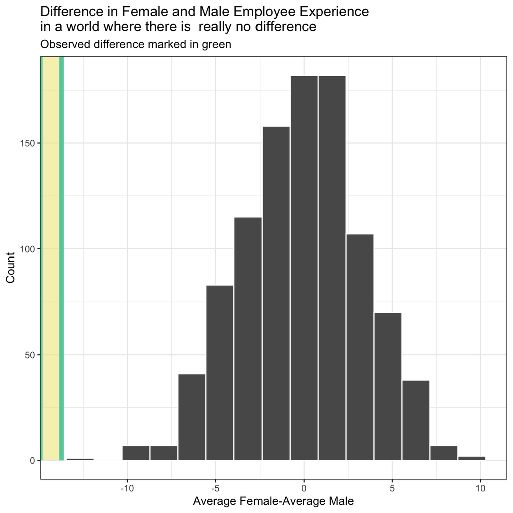

```r
# hypothesis testing using infer package
set.seed(1212)
experience_in_null_world <- omega %>%
  #specify the variable of interest
  specify(experience~gender) %>%
  #Hypothesize a null of no difference
  hypothesise(null="independence") %>%
  #Generate a bunch of simulated samples
  generate(reps = 1000, type="permute") %>%
  #Find the mean difference of each sample
  calculate(stat="diff in means",
            order = c("female","male"))

#Visualize data and check where the observed sample difference falls
obs_diff_exp=7.38-21.12
experience_in_null_world %>% visualize() +
  shade_ci(endpoints=c(-Inf,obs_diff_exp),fill = "khaki")+
  labs(title='Difference in Female and Male Employee Experience
in a world where there is  really no difference',
       subtitle = 'Observed difference marked in green',
        y='Count',
        x='Average Female-Average Male')+
  theme_bw()+
  NULL
```

```r
#Calculate a p-value, or the probability that we would see the green line at
experience_in_null_world %>%
  get_pvalue(obs_stat = obs_diff_exp,direction = "both")
```

```
## # A tibble: 1 x 1
##   p_value
##     <dbl>
## 1       0
```

> From t-test, we can see that the 95% CI range is negative and does not include zero.The p-value 1e-05 is also very small. This indicates that male excutives indeed have more experience. With the simulation method, we can see from the plot that the observed difference falls in the far left of the plot. We also calculated a p-value of almost zero, which is again very small. This result indicates that male excutives indeed have more experience as well. The result male executives having more experience endangers the previous result - male executives have higher salaries. For now it is possible that the salary differences result from experience gap instead gender difference.

## 1.4 Relationship Salary - Experience ?

Someone at the meeting argues that clearly, a more thorough analysis of the relationship between salary and experience is required before any conclusion can be drawn about whether there is any gender-based salary discrimination in the company.

Therefore, we will analyze the relationship between salary and experience. Below, we draw a scatterplot to visually explore the data.

```r
#correlation test between salary and experience
cor.test(omega$salary,omega$experience,method="pearson")
```

```
##
##  Pearson's product-moment correlation
##
## data:  x and y
## t = 9, df = 48, p-value = 2e-12
## alternative hypothesis: true correlation is not equal to 0
## 95 percent confidence interval:
##  0.676 0.884
## sample estimates:
##   cor
## 0.803
```

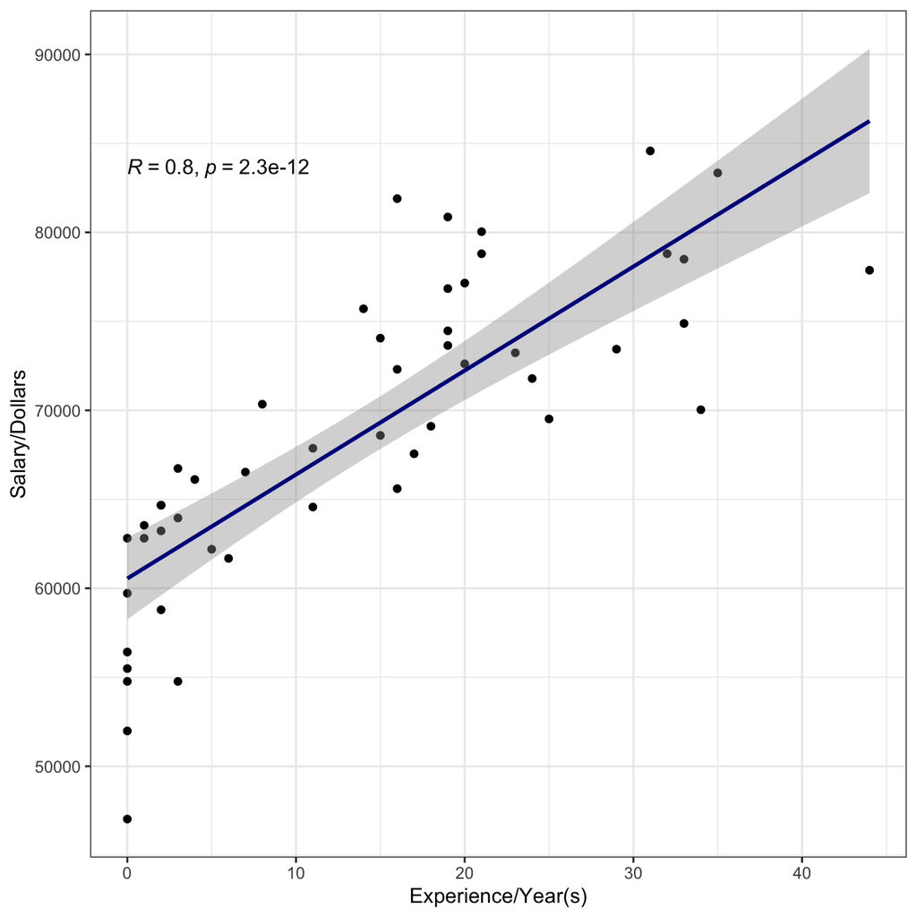

```r
#visualize the data
library(ggpubr)
ggplot(omega,aes(x=experience,y=salary))+
  theme_bw()+
  labs(x="Experience/Year(s)",y="Salary/Dollars")+
  geom_point()+
  stat_smooth(method="lm",se=TRUE,color="darkblue")+
  stat_cor(method = "pearson")
```

> There is an obvious positive correlation between experience and salary, with the correlation value as high as 0.8. The degree of freedom is 48 and p-value is 2.257e-12 < 0.05(the p-value under df=48).Thus, the correlation between the two variables is significant.